# Team_spunk_Mulytics

## Step-by-Step Analysis for Lead Installation Forecasting

### **Objective**

This analysis aims to address the challenges faced by a leading broadband provider in optimizing lead conversion processes. The goal is to:

1. **Optimize the Lead Funnel**:
   - Segment customers to identify high-conversion leads.
   - Allocate marketing budgets efficiently.
   - Prioritize high-potential leads for follow-ups.
2. **Develop a Predictive Model**:
   - Identify features impacting lead conversions.
   - Build models to predict lead installation success.

### **Tools and Techniques Used**

- **Libraries**: `pandas`, `numpy`, `seaborn`, `matplotlib`, `scikit-learn`, `XGBoost`, `imblearn`.
- **Preprocessing**:
  - Missing value imputation.
  - Encoding categorical variables.
  - Balancing classes with **SMOTE**.
- **Visualization**:
  - Heatmaps, countplots, histograms, and barplots.
- **Machine Learning Models**:
  - Random Forest, XGBoost, and Voting Classifier.

### **Key Deliverables**

1. **Data Cleaning and EDA**:
   - Insights into lead behaviors and operational metrics.
2. **Feature Importance Analysis**:
   - Identification of critical predictors for conversions.
3. **Predictive Model Performance**:
   - Models evaluated on precision, recall, and ROC-AUC score.
4. **Actionable Recommendations**:
   - Strategies for improving lead prioritization and marketing efficiency.

```python
import numpy as np
import pandas as pd
import matplotlib.pyplot as plt
import seaborn as sns
from sklearn.preprocessing import LabelEncoder
from imblearn.over_sampling import SMOTE
from sklearn.model_selection import train_test_split
from sklearn.linear_model import LogisticRegression
from sklearn.ensemble import RandomForestClassifier, VotingClassifier
from xgboost import XGBClassifier
from sklearn.metrics import classification_report, confusion_matrix, roc_auc_score, roc_curve
import warnings

warnings.filterwarnings('ignore')
```

```python
# Read the data from csv file

df = pd.read_csv('Mulytics_Dataset.csv')
```

```python
# Check the head of the dataset

df.head()
```

|  | Lead ID | City | Plan Type | Household Income Level | Lead Source | Marketing Channel | Lead Created Date | Follow-Up Count | Competitor Interest | Preferred Contact Time | ... | Service Quality Rating | Time Spent on Research (Days) | Preferred Communication Mode | Days to Accept | Days to Qualify | Days to Install Request | Installed | Is Holiday | Festive Period | Day of the Week |
| --- | --- | --- | --- | --- | --- | --- | --- | --- | --- | --- | --- | --- | --- | --- | --- | --- | --- | --- | --- | --- | --- |
| 0 | L10000 | Mumbai | Basic | Medium | Social Media | Email Campaign | 29-03-2023 | 2 | Yes | Evening | ... | 4 | 2 | Call | 1.0 | NaN | NaN | 0 | 0 | 0 | Wednesday |
| 1 | L10001 | Bangalore | Basic | Low | Website | Organic | 15-11-2023 | 5 | Yes | Morning | ... | 5 | 10 | Call | 5.0 | 1.0 | NaN | 0 | 0 | 1 | Wednesday |
| 2 | L10002 | Bangalore | Premium | High | Social Media | Facebook Ads | 28-09-2023 | 2 | No | Evening | ... | 1 | 12 | Call | 4.0 | 6.0 | NaN | 0 | 0 | 0 | Thursday |
| 3 | L10003 | Hyderabad | Premium | Medium | Walk-in | Google Ads | 15-05-2023 | 3 | No | Morning | ... | 5 | 17 | Email | 6.0 | 7.0 | NaN | 0 | 0 | 0 | Monday |
| 4 | L10004 | Hyderabad | Standard | Medium | Walk-in | Facebook Ads | 31-01-2023 | 3 | Yes | Afternoon | ... | 5 | 12 | SMS | 5.0 | 6.0 | 17.0 | 0 | 0 | 0 | Tuesday |

5 rows × 36 columns

# Step 1: Feature engineering and analysis

```python
# Initial exploration
def initial_analysis(df):
    print("Dataset Info:")
    print(df.info())
    print("\nMissing Values:")
    print(df.isnull().sum())
    print("\nSample Data:")
    print(df.head())
initial_analysis(df)
```

```
Dataset Info:
<class 'pandas.core.frame.DataFrame'>
RangeIndex: 100000 entries, 0 to 99999
Data columns (total 36 columns):
 #   Column                         Non-Null Count   Dtype
---  ------                         --------------   -----
 0   Lead ID                        100000 non-null  object
 1   City                           100000 non-null  object
 2   Plan Type                      100000 non-null  object
 3   Household Income Level         100000 non-null  object
 4   Lead Source                    100000 non-null  object
 5   Marketing Channel              100000 non-null  object
 6   Lead Created Date              100000 non-null  object
 7   Follow-Up Count                100000 non-null  int64
 8   Competitor Interest            100000 non-null  object
 9   Preferred Contact Time         100000 non-null  object
 10  Customer Tech-Savviness        100000 non-null  object
 11  Decision Influence             100000 non-null  object
 12  Complaint History              100000 non-null  object
 13  Payment Mode Preferred         100000 non-null  object
 14  Payment Frequency              100000 non-null  object
 15  Discount Availed (INR)         100000 non-null  int64
 16  Marketing Spend (INR)          100000 non-null  int64
 17  Plan Cost (INR)                100000 non-null  int64
 18  Average Monthly Spend (INR)    100000 non-null  int64
 19  Lifetime Value (INR)           100000 non-null  int64
 20  Bundled Service Interest       100000 non-null  object
 21  Competitor Price Sensitivity   100000 non-null  object
 22  Distance to Service Hub        100000 non-null  int64
 23  Infrastructure Ready           100000 non-null  object
 24  Network Downtime (Hours)       100000 non-null  int64
 25  Signal Strength                100000 non-null  object
 26  Service Quality Rating         100000 non-null  int64
 27  Time Spent on Research (Days)  100000 non-null  int64
 28  Preferred Communication Mode   100000 non-null  object
 29  Days to Accept                 84987 non-null   float64
 30  Days to Qualify                59518 non-null   float64
 31  Days to Install Request        29878 non-null   float64
 32  Installed                      100000 non-null  int64
 33  Is Holiday                     100000 non-null  int64
```

[output cut: 74 more lines]

```
  Days to Qualify  Days to Install Request  Installed  Is Holiday  \
0             NaN                      NaN          0           0
1             1.0                      NaN          0           0
2             6.0                      NaN          0           0
3             7.0                      NaN          0           0
4             6.0                     17.0          0           0

   Festive Period  Day of the Week
0               0        Wednesday
1               1        Wednesday
2               0         Thursday
3               0           Monday
4               0          Tuesday

[5 rows x 36 columns]
```

```python
# Renaming columns for better readability
df.rename(columns={
    'Lead ID': 'lead_id',
    'Plan Type': 'plan_type',
    'Household Income Level': 'household_income_level',
    'Lead Source': 'lead_source',
    'Marketing Channel': 'marketing_channel',
    'Lead Created Date': 'lead_created_date',
    'Follow-Up Count': 'follow_up_count',
    'Competitor Interest': 'competitor_interest',
    'Preferred Contact Time': 'preferred_contact_time',
    'Customer Tech-Savviness': 'customer_tech_savviness',
    'Decision Influence': 'decision_influence',
    'Complaint History': 'complaint_history',
    'Payment Mode Preferred': 'payment_mode_preferred',
    'Payment Frequency': 'payment_frequency',
    'Discount Availed (INR)': 'discount_availed_inr',
    'Marketing Spend (INR)': 'marketing_spend_inr',
    'Plan Cost (INR)': 'plan_cost_inr',
    'Average Monthly Spend (INR)': 'average_monthly_spend_inr',
    'Lifetime Value (INR)': 'lifetime_value_inr',
    'Bundled Service Interest': 'bundled_service_interest',
    'Competitor Price Sensitivity': 'competitor_price_sensitivity',
    'Distance to Service Hub': 'distance_to_service_hub',
    'Infrastructure Ready': 'infrastructure_ready',
    'Network Downtime (Hours)': 'network_downtime_hours',
    'Signal Strength': 'signal_strength',
    'Service Quality Rating': 'service_quality_rating',
    'Time Spent on Research (Days)': 'time_spent_on_research_days',
    'Preferred Communication Mode': 'preferred_communication_mode',
    'Days to Accept': 'days_to_accept',
    'Days to Qualify': 'days_to_qualify',
    'Days to Install Request': 'days_to_install_request',
    'Installed': 'installed',
    'Is Holiday': 'is_holiday',
    'Festive Period': 'festive_period',
    'Day of the Week': 'day_of_the_week'
}, inplace=True)
```

```python
# Check the head of the dataset

df.head()
```

|  | lead_id | City | plan_type | household_income_level | lead_source | marketing_channel | lead_created_date | follow_up_count | competitor_interest | preferred_contact_time | ... | service_quality_rating | time_spent_on_research_days | preferred_communication_mode | days_to_accept | days_to_qualify | days_to_install_request | installed | is_holiday | festive_period | day_of_the_week |
| --- | --- | --- | --- | --- | --- | --- | --- | --- | --- | --- | --- | --- | --- | --- | --- | --- | --- | --- | --- | --- | --- |
| 0 | L10000 | Mumbai | Basic | Medium | Social Media | Email Campaign | 29-03-2023 | 2 | Yes | Evening | ... | 4 | 2 | Call | 1.0 | NaN | NaN | 0 | 0 | 0 | Wednesday |
| 1 | L10001 | Bangalore | Basic | Low | Website | Organic | 15-11-2023 | 5 | Yes | Morning | ... | 5 | 10 | Call | 5.0 | 1.0 | NaN | 0 | 0 | 1 | Wednesday |
| 2 | L10002 | Bangalore | Premium | High | Social Media | Facebook Ads | 28-09-2023 | 2 | No | Evening | ... | 1 | 12 | Call | 4.0 | 6.0 | NaN | 0 | 0 | 0 | Thursday |
| 3 | L10003 | Hyderabad | Premium | Medium | Walk-in | Google Ads | 15-05-2023 | 3 | No | Morning | ... | 5 | 17 | Email | 6.0 | 7.0 | NaN | 0 | 0 | 0 | Monday |
| 4 | L10004 | Hyderabad | Standard | Medium | Walk-in | Facebook Ads | 31-01-2023 | 3 | Yes | Afternoon | ... | 5 | 12 | SMS | 5.0 | 6.0 | 17.0 | 0 | 0 | 0 | Tuesday |

5 rows × 36 columns

```python
# Handle missing values for specific columns
# 1. For 'Days to Accept' (15% missing): Fill with median
df['days_to_accept'].fillna(df['days_to_accept'].median(), inplace=True)

# 2. For 'Days to Qualify' (40% missing): Consider filling with median or -1 to indicate missing
df['days_to_qualify'].fillna(df['days_to_qualify'].median(), inplace=True)

# 3. For 'Days to Install Request' (70% missing): Consider dropping this column or imputing with a placeholder
df['days_to_install_request'].fillna(-1, inplace=True)  # -1 to indicate missing data explicitly

# Verify changes
print("Missing values after handling:")
print(df[['days_to_accept', 'days_to_qualify', 'days_to_install_request']].isnull().sum())
```

```
Missing values after handling:
days_to_accept             0
days_to_qualify            0
days_to_install_request    0
dtype: int64
```

```python
df.head()
```

|  | lead_id | City | plan_type | household_income_level | lead_source | marketing_channel | lead_created_date | follow_up_count | competitor_interest | preferred_contact_time | ... | service_quality_rating | time_spent_on_research_days | preferred_communication_mode | days_to_accept | days_to_qualify | days_to_install_request | installed | is_holiday | festive_period | day_of_the_week |
| --- | --- | --- | --- | --- | --- | --- | --- | --- | --- | --- | --- | --- | --- | --- | --- | --- | --- | --- | --- | --- | --- |
| 0 | L10000 | Mumbai | Basic | Medium | Social Media | Email Campaign | 29-03-2023 | 2 | Yes | Evening | ... | 4 | 2 | Call | 1.0 | 6.0 | -1.0 | 0 | 0 | 0 | Wednesday |
| 1 | L10001 | Bangalore | Basic | Low | Website | Organic | 15-11-2023 | 5 | Yes | Morning | ... | 5 | 10 | Call | 5.0 | 1.0 | -1.0 | 0 | 0 | 1 | Wednesday |
| 2 | L10002 | Bangalore | Premium | High | Social Media | Facebook Ads | 28-09-2023 | 2 | No | Evening | ... | 1 | 12 | Call | 4.0 | 6.0 | -1.0 | 0 | 0 | 0 | Thursday |
| 3 | L10003 | Hyderabad | Premium | Medium | Walk-in | Google Ads | 15-05-2023 | 3 | No | Morning | ... | 5 | 17 | Email | 6.0 | 7.0 | -1.0 | 0 | 0 | 0 | Monday |
| 4 | L10004 | Hyderabad | Standard | Medium | Walk-in | Facebook Ads | 31-01-2023 | 3 | Yes | Afternoon | ... | 5 | 12 | SMS | 5.0 | 6.0 | 17.0 | 0 | 0 | 0 | Tuesday |

5 rows × 36 columns

```python
# Identify categorical columns
categorical_columns = df.select_dtypes(include=['object']).columns

# Apply One-Hot Encoding for nominal variables using pd.get_dummies
df = pd.get_dummies(df, columns=['City', 'marketing_channel', 'preferred_communication_mode'], drop_first=True)

# Apply Label Encoding for ordinal variables
from sklearn.preprocessing import LabelEncoder

# Example: Assuming 'household_income_level' is ordinal
ordinal_columns = ['household_income_level']
le = LabelEncoder()
for col in ordinal_columns:
    df[col] = le.fit_transform(df[col])

# Verify encoded columns
print("Columns after encoding:\n", df.columns)
```

```
Columns after encoding:
 Index(['lead_id', 'plan_type', 'household_income_level', 'lead_source',
       'lead_created_date', 'follow_up_count', 'competitor_interest',
       'preferred_contact_time', 'customer_tech_savviness',
       'decision_influence', 'complaint_history', 'payment_mode_preferred',
       'payment_frequency', 'discount_availed_inr', 'marketing_spend_inr',
       'plan_cost_inr', 'average_monthly_spend_inr', 'lifetime_value_inr',
       'bundled_service_interest', 'competitor_price_sensitivity',
       'distance_to_service_hub', 'infrastructure_ready',
       'network_downtime_hours', 'signal_strength', 'service_quality_rating',
       'time_spent_on_research_days', 'days_to_accept', 'days_to_qualify',
       'days_to_install_request', 'installed', 'is_holiday', 'festive_period',
       'day_of_the_week', 'City_Chennai', 'City_Delhi', 'City_Hyderabad',
       'City_Mumbai', 'marketing_channel_Facebook Ads',
       'marketing_channel_Google Ads', 'marketing_channel_Organic',
       'preferred_communication_mode_Email',
       'preferred_communication_mode_SMS'],
      dtype='object')
```

```python
df.head()
```

|  | lead_id | plan_type | household_income_level | lead_source | lead_created_date | follow_up_count | competitor_interest | preferred_contact_time | customer_tech_savviness | decision_influence | ... | day_of_the_week | City_Chennai | City_Delhi | City_Hyderabad | City_Mumbai | marketing_channel_Facebook Ads | marketing_channel_Google Ads | marketing_channel_Organic | preferred_communication_mode_Email | preferred_communication_mode_SMS |
| --- | --- | --- | --- | --- | --- | --- | --- | --- | --- | --- | --- | --- | --- | --- | --- | --- | --- | --- | --- | --- | --- |
| 0 | L10000 | Basic | 2 | Social Media | 29-03-2023 | 2 | Yes | Evening | Medium | Pricing | ... | Wednesday | False | False | False | True | False | False | False | False | False |
| 1 | L10001 | Basic | 1 | Website | 15-11-2023 | 5 | Yes | Morning | Low | Pricing | ... | Wednesday | False | False | False | False | False | False | True | False | False |
| 2 | L10002 | Premium | 0 | Social Media | 28-09-2023 | 2 | No | Evening | High | Pricing | ... | Thursday | False | False | False | False | True | False | False | False | False |
| 3 | L10003 | Premium | 2 | Walk-in | 15-05-2023 | 3 | No | Morning | Medium | Customer Reviews | ... | Monday | False | False | True | False | False | True | False | True | False |
| 4 | L10004 | Standard | 2 | Walk-in | 31-01-2023 | 3 | Yes | Afternoon | High | Customer Reviews | ... | Tuesday | False | False | True | False | True | False | False | False | True |

5 rows × 42 columns

```python
print(df['installed'].value_counts(normalize=True))
```

```
installed
0    0.82028
1    0.17972
Name: proportion, dtype: float64
```

```python
# Ensure all categorical columns are encoded
categorical_columns = df.select_dtypes(include=['object']).columns

# Use Label Encoding for simplicity (you can also use One-Hot Encoding if preferred)
le = LabelEncoder()
for col in categorical_columns:
    df[col] = le.fit_transform(df[col])

# Split data into features (X) and target (y)
X = df.drop('installed', axis=1)  # Drop the target column
y = df['installed']  # Target column

# Split data into training and testing sets
X_train, X_test, y_train, y_test = train_test_split(X, y, test_size=0.2, random_state=42, stratify=y)

# Apply SMOTE to the training set
smote = SMOTE(random_state=42)
X_train_resampled, y_train_resampled = smote.fit_resample(X_train, y_train)

# Verify the class distribution after SMOTE
print("Class distribution before SMOTE:\n", y_train.value_counts())
print("Class distribution after SMOTE:\n", pd.Series(y_train_resampled).value_counts())
```

```
Class distribution before SMOTE:
 installed
0    65622
1    14378
Name: count, dtype: int64
Class distribution after SMOTE:
 installed
0    65622
1    65622
Name: count, dtype: int64
```

## Step 2: Visualising the Data/EDA

```python
# Set visualization styles
sns.set(style="whitegrid")

# Function for initial dataset overview
def dataset_overview(df):
    print("Dataset Info:")
    print(df.info())
    print("\nMissing Values (%):")
    print(df.isnull().mean() * 100)
    print("\nSummary Statistics:")
    print(df.describe())

# Initial overview
dataset_overview(df)
```

```
Dataset Info:
<class 'pandas.core.frame.DataFrame'>
RangeIndex: 100000 entries, 0 to 99999
Data columns (total 42 columns):
 #   Column                              Non-Null Count   Dtype
---  ------                              --------------   -----
 0   lead_id                             100000 non-null  int64
 1   plan_type                           100000 non-null  int64
 2   household_income_level              100000 non-null  int64
 3   lead_source                         100000 non-null  int64
 4   lead_created_date                   100000 non-null  int64
 5   follow_up_count                     100000 non-null  int64
 6   competitor_interest                 100000 non-null  int64
 7   preferred_contact_time              100000 non-null  int64
 8   customer_tech_savviness             100000 non-null  int64
 9   decision_influence                  100000 non-null  int64
 10  complaint_history                   100000 non-null  int64
 11  payment_mode_preferred              100000 non-null  int64
 12  payment_frequency                   100000 non-null  int64
 13  discount_availed_inr                100000 non-null  int64
 14  marketing_spend_inr                 100000 non-null  int64
 15  plan_cost_inr                       100000 non-null  int64
 16  average_monthly_spend_inr           100000 non-null  int64
 17  lifetime_value_inr                  100000 non-null  int64
 18  bundled_service_interest            100000 non-null  int64
 19  competitor_price_sensitivity        100000 non-null  int64
 20  distance_to_service_hub             100000 non-null  int64
 21  infrastructure_ready                100000 non-null  int64
 22  network_downtime_hours              100000 non-null  int64
 23  signal_strength                     100000 non-null  int64
 24  service_quality_rating              100000 non-null  int64
 25  time_spent_on_research_days         100000 non-null  int64
 26  days_to_accept                      100000 non-null  float64
 27  days_to_qualify                     100000 non-null  float64
 28  days_to_install_request             100000 non-null  float64
 29  installed                           100000 non-null  int64
 30  is_holiday                          100000 non-null  int64
 31  festive_period                      100000 non-null  int64
 32  day_of_the_week                     100000 non-null  int64
 33  City_Chennai                        100000 non-null  bool
```

[output cut: 114 more lines]

```
50%                  -1.000000       0.000000       0.000000        0.000000
75%                   9.000000       0.000000       0.000000        1.000000
max                  24.000000       1.000000       1.000000        1.000000

       day_of_the_week
count    100000.000000
mean          3.000510
std           1.992644
min           0.000000
25%           1.000000
50%           3.000000
75%           5.000000
max           6.000000

[8 rows x 33 columns]
```

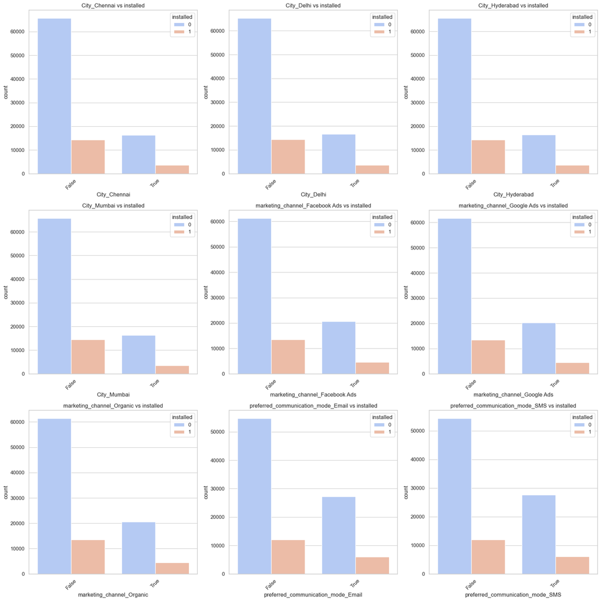

```python
# Function to create barplots in a 3x3 grid for categorical columns
def plot_categorical_barplots(df, categorical_columns, target_column):

    # Determine the grid size
    num_columns = len(categorical_columns)
    num_rows = (num_columns + 2) // 3  # Ceiling division for 3 columns per row

    # Set the plot size
    plt.figure(figsize=(18, num_rows * 6))
    sns.set(style="whitegrid")

    for i, col in enumerate(categorical_columns):
        plt.subplot(num_rows, 3, i + 1)
        sns.countplot(data=df, x=col, hue=target_column, palette="coolwarm")
        plt.title(f"{col} vs {target_column}")
        plt.xticks(rotation=45)
        plt.tight_layout()

    plt.show()

# Updated categorical columns based on provided data
categorical_columns = [
    'City_Chennai', 'City_Delhi', 'City_Hyderabad', 'City_Mumbai',
    'marketing_channel_Facebook Ads', 'marketing_channel_Google Ads',
    'marketing_channel_Organic', 'preferred_communication_mode_Email',
    'preferred_communication_mode_SMS'
]

# Call the function with the dataset
plot_categorical_barplots(df, categorical_columns, 'installed')
```

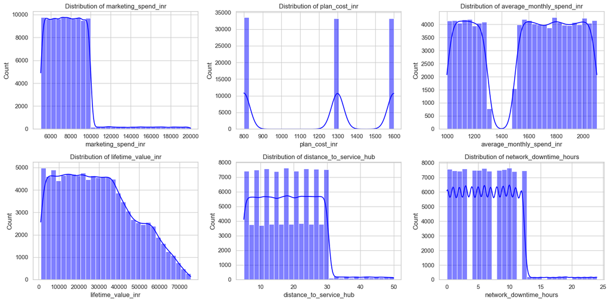

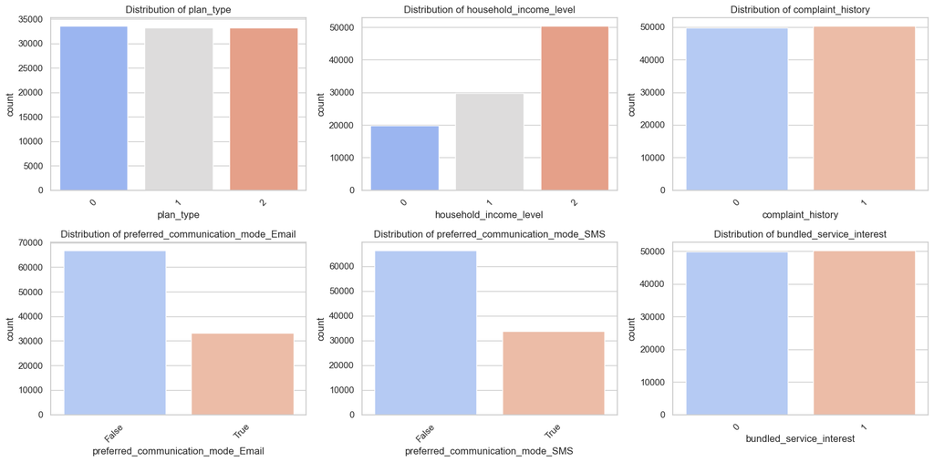

```python
def univariate_analysis_with_grid(df, numerical_features, categorical_features):


    # Set plot style
    sns.set(style="whitegrid")

    # Numerical Features: Histograms in a 3x3 grid
    num_rows = (len(numerical_features) + 2) // 3
    plt.figure(figsize=(16, num_rows * 4))
    for i, feature in enumerate(numerical_features, 1):
        plt.subplot(num_rows, 3, i)
        sns.histplot(df[feature], kde=True, color="blue", bins=30)
        plt.title(f'Distribution of {feature}')
    plt.tight_layout()
    plt.show()

    # Categorical Features: Countplots in a 3x3 grid
    num_rows = (len(categorical_features) + 2) // 3
    plt.figure(figsize=(16, num_rows * 4))
    for i, feature in enumerate(categorical_features, 1):
        plt.subplot(num_rows, 3, i)
        if feature in df.columns:
            sns.countplot(data=df, x=feature, palette="coolwarm")
            plt.title(f'Distribution of {feature}')
            plt.xticks(rotation=45)
        else:
            print(f"Warning: Column '{feature}' not found in the dataset.")
    plt.tight_layout()
    plt.show()

# Updated numerical and categorical feature lists
numerical_features = [
    'marketing_spend_inr', 'plan_cost_inr', 'average_monthly_spend_inr',
    'lifetime_value_inr', 'distance_to_service_hub', 'network_downtime_hours'
]

categorical_features = [
    'plan_type', 'household_income_level', 'complaint_history',
    'preferred_communication_mode_Email', 'preferred_communication_mode_SMS',
    'bundled_service_interest'
]

# Call the function
univariate_analysis_with_grid(df, numerical_features, categorical_features)
```

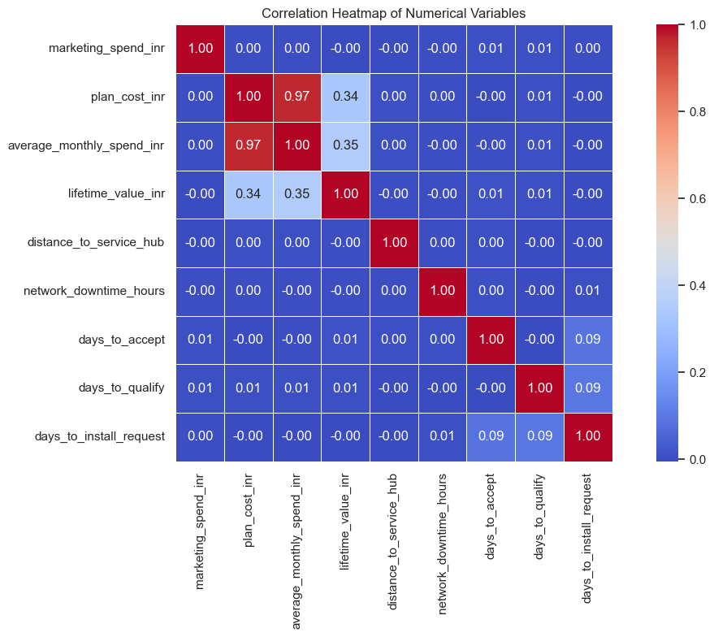

```python
# Function to plot the correlation heatmap for numerical variables
def plot_correlation_heatmap(df, numerical_columns):

    # Compute the correlation matrix
    correlation_matrix = df[numerical_columns].corr()

    # Plot the heatmap
    plt.figure(figsize=(12, 8))
    sns.heatmap(
        correlation_matrix,
        annot=True,
        fmt=".2f",
        cmap="coolwarm",
        cbar=True,
        square=True,
        linewidths=0.5
    )
    plt.title("Correlation Heatmap of Numerical Variables")
    plt.tight_layout()
    plt.show()

# Numerical columns based on the dataset
numerical_columns = [
    'marketing_spend_inr', 'plan_cost_inr', 'average_monthly_spend_inr',
    'lifetime_value_inr', 'distance_to_service_hub', 'network_downtime_hours',
    'days_to_accept', 'days_to_qualify', 'days_to_install_request'
]

# Call the function with the dataset
plot_correlation_heatmap(df, numerical_columns)
```

# Step 3: Predictive Modelling and Interpretation

```
Classification Report:
               precision    recall  f1-score   support

           0       0.98      0.86      0.92     16406
           1       0.60      0.93      0.73      3594

    accuracy                           0.87     20000
   macro avg       0.79      0.90      0.82     20000
weighted avg       0.91      0.87      0.88     20000

Confusion Matrix:
```

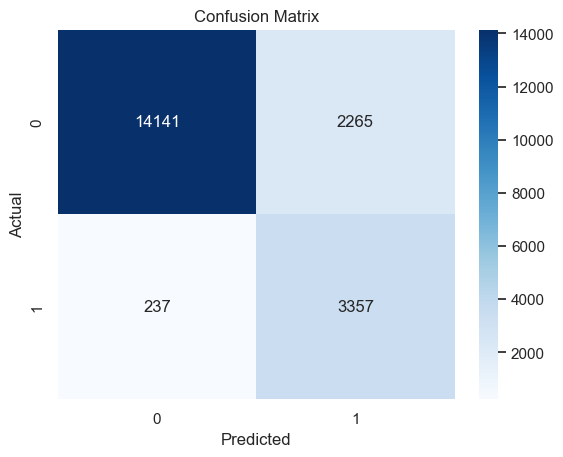

```
ROC-AUC Score: 0.93
```

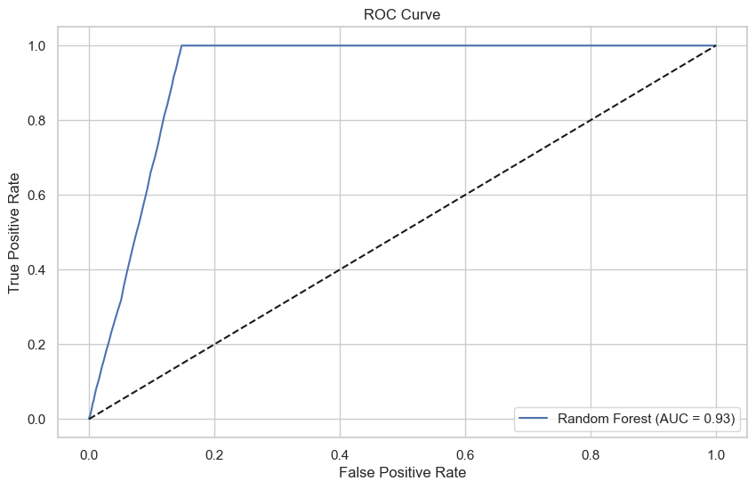

```
Top Features:
                       Feature  Importance
28    days_to_install_request    0.517451
27            days_to_qualify    0.103244
12          payment_frequency    0.016749
23            signal_strength    0.015821
16  average_monthly_spend_inr    0.015695
4           lead_created_date    0.015562
26             days_to_accept    0.015104
14        marketing_spend_inr    0.014890
13       discount_availed_inr    0.014651
6         competitor_interest    0.014611
```

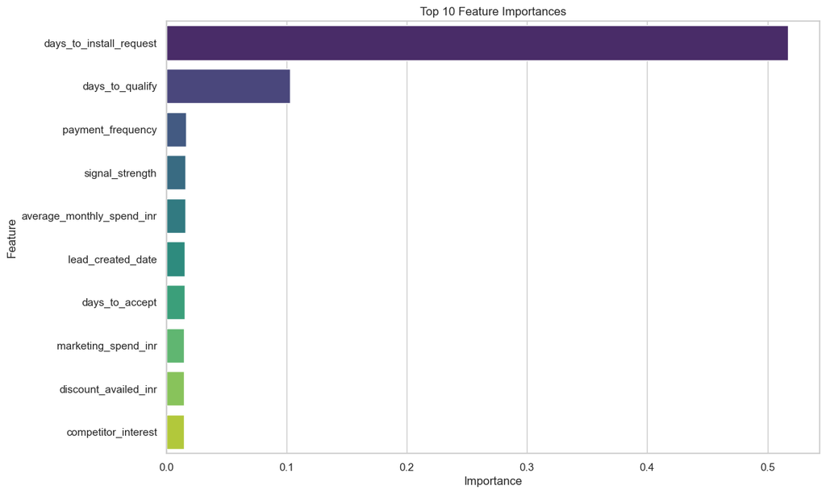

```python
# Initialize the Random Forest model
rf_model = RandomForestClassifier(random_state=42)

# Train the model
rf_model.fit(X_train_resampled, y_train_resampled)

# Predict on the test set
y_pred = rf_model.predict(X_test)

# Evaluate the model
print("Classification Report:\n", classification_report(y_test, y_pred))
print("Confusion Matrix:\n")
sns.heatmap(confusion_matrix(y_test, y_pred), annot=True, fmt='d', cmap="Blues")
plt.title("Confusion Matrix")
plt.xlabel("Predicted")
plt.ylabel("Actual")
plt.show()

# Calculate ROC-AUC score
y_proba = rf_model.predict_proba(X_test)[:, 1]
roc_score = roc_auc_score(y_test, y_proba)
print(f"ROC-AUC Score: {roc_score:.2f}")

# Plot ROC Curve
fpr, tpr, _ = roc_curve(y_test, y_proba)
plt.figure(figsize=(10, 6))
plt.plot(fpr, tpr, label=f"Random Forest (AUC = {roc_score:.2f})")
plt.plot([0, 1], [0, 1], 'k--')
plt.title("ROC Curve")
plt.xlabel("False Positive Rate")
plt.ylabel("True Positive Rate")
plt.legend()
plt.show()

# Feature Importance
feature_importances = rf_model.feature_importances_
important_features = pd.DataFrame({
    'Feature': X_train.columns,
    'Importance': feature_importances
}).sort_values(by='Importance', ascending=False)
print("Top Features:\n", important_features.head(10))

# Plot feature importance
plt.figure(figsize=(12, 8))
sns.barplot(data=important_features.head(10), x='Importance', y='Feature', palette="viridis")
plt.title("Top 10 Feature Importances")
plt.show()
```

# Interpretation of Results

## 1. Classification Report

### Recall:

- **Class 1 (Installed)**: High recall (0.93) shows the model captures most true positives (leads that converted).
- **Class 0 (Not Installed)**: Lower recall (0.86) indicates some false negatives for this class.

### F1-Score:

- Balanced performance for both classes, weighted more towards Class 0 due to its higher prevalence.

## 2. ROC-AUC Score

- **Score**: 0.93
- Indicates excellent model performance in distinguishing between the two classes.

## 3. Confusion Matrix

- The model correctly identifies most leads as either installed or not installed.
- There’s room for improvement in reducing false positives and false negatives.

## 4. Feature Importance

### Top Features:

- **days_to_install_request (52%)**: The most critical predictor for conversion.
- **days_to_qualify (10%)**: Indicates the lead’s journey through the funnel.
- Features related to customer behavior (payment_frequency, signal_strength, etc.) and financial metrics (marketing_spend_inr, discount_availed_inr) are influential.

```
XGBoost Classification Report:
               precision    recall  f1-score   support

           0       0.95      0.89      0.92     16406
           1       0.60      0.79      0.68      3594

    accuracy                           0.87     20000
   macro avg       0.78      0.84      0.80     20000
weighted avg       0.89      0.87      0.88     20000

XGBoost ROC-AUC Score: 0.93
```

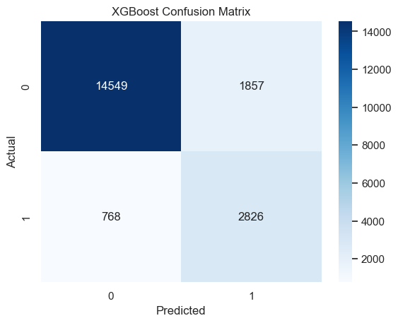

```python
# Train an XGBoost model
xgb_model = XGBClassifier(random_state=42, use_label_encoder=False, eval_metric='logloss')
xgb_model.fit(X_train_resampled, y_train_resampled)

# Evaluate the model
y_pred_xgb = xgb_model.predict(X_test)
y_proba_xgb = xgb_model.predict_proba(X_test)[:, 1]

# Classification Report
print("XGBoost Classification Report:\n", classification_report(y_test, y_pred_xgb))

# ROC-AUC Score
roc_auc_xgb = roc_auc_score(y_test, y_proba_xgb)
print(f"XGBoost ROC-AUC Score: {roc_auc_xgb:.2f}")

# Confusion Matrix
sns.heatmap(confusion_matrix(y_test, y_pred_xgb), annot=True, fmt='d', cmap="Blues")
plt.title("XGBoost Confusion Matrix")
plt.xlabel("Predicted")
plt.ylabel("Actual")
plt.show()
```

```python
# Define individual models
log_reg = LogisticRegression(random_state=42, max_iter=1000)
rf_model = RandomForestClassifier(random_state=42)
xgb_model = XGBClassifier(random_state=42, use_label_encoder=False, eval_metric='logloss')

# Create a Voting Classifier
voting_clf = VotingClassifier(estimators=[
    ('log_reg', log_reg),
    ('rf', rf_model),
    ('xgb', xgb_model)
], voting='soft')  # Use 'soft' for averaging probabilities

# Train the ensemble model
voting_clf.fit(X_train_resampled, y_train_resampled)

# Predict and evaluate
y_pred_voting = voting_clf.predict(X_test)
y_proba_voting = voting_clf.predict_proba(X_test)[:, 1]

print("Voting Classifier Classification Report:\n", classification_report(y_test, y_pred_voting))
print(f"Voting Classifier ROC-AUC Score: {roc_auc_score(y_test, y_proba_voting):.2f}")
```

```
Voting Classifier Classification Report:
               precision    recall  f1-score   support

           0       0.99      0.86      0.92     16406
           1       0.60      0.95      0.73      3594

    accuracy                           0.88     20000
   macro avg       0.79      0.90      0.83     20000
weighted avg       0.92      0.88      0.89     20000

Voting Classifier ROC-AUC Score: 0.93
```

## Analysis and Interpretation

### **Voting Classifier Results**

- **Classification Report**:
  - **Class 0 (Not Installed)**:
    - **Precision**: 0.99 (Very high, minimal false positives).
    - **Recall**: 0.86 (Misses some non-installed leads).
  - **Class 1 (Installed)**:
    - **Precision**: 0.60 (Moderate, some false positives).
    - **Recall**: 0.95 (Excellent at capturing true conversions).
- **ROC-AUC Score**: 0.93 (Consistently strong ability to distinguish between classes).
- **Accuracy**: 88% (Improved slightly from individual models).

### **Model Comparison**

| Metric | Random Forest | XGBoost | Voting Classifier |
| --- | --- | --- | --- |
| Precision (Class 0) | 0.98 | 0.95 | **0.99** |
| Recall (Class 0) | 0.86 | **0.89** | 0.86 |
| Precision (Class 1) | 0.60 | **0.60** | **0.60** |
| Recall (Class 1) | **0.93** | 0.79 | **0.95** |
| Accuracy | 87% | 87% | **88%** |
| ROC-AUC Score | 0.93 | 0.93 | 0.93 |

## Recommendations

### **2. Model Enhancements**

- **Fine-Tune Voting Weights**:
  - Adjust model contributions to further balance recall and precision.
- **Explore Stacking**:
  - Use a meta-model (e.g., Logistic Regression) to combine predictions from Random Forest and XGBoost for potentially better performance.

### **3. Deployment Strategy**

- Integrate the Voting Classifier into the lead management system to score and prioritize leads dynamically.
- Regularly retrain the model with updated data to maintain performance.

The **Voting Classifier** demonstrates a robust balance of precision and recall, making it an ideal choice for optimizing lead prioritization and improving resource efficiency.

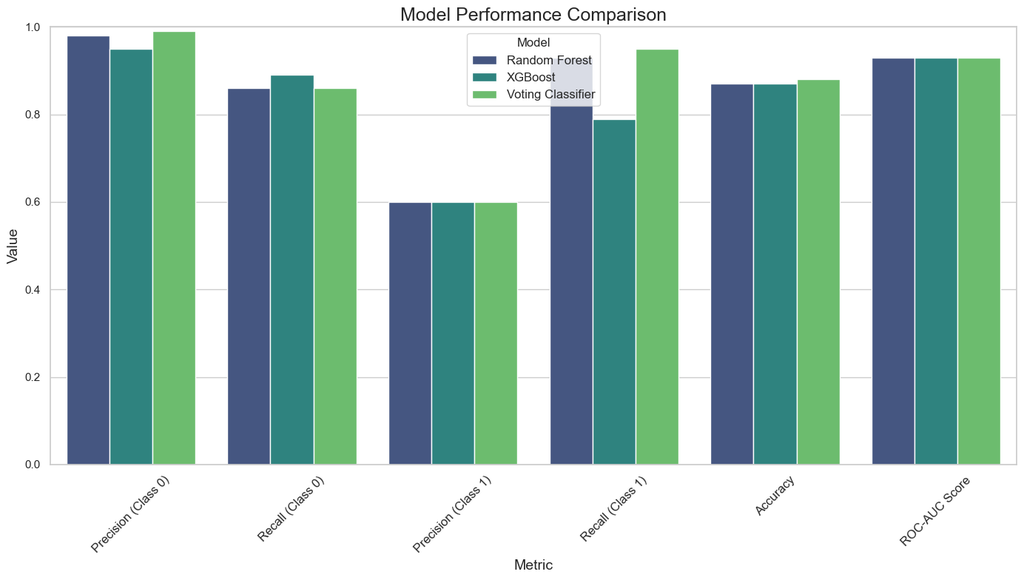

```python
# Provided performance metrics for models
model_performance = {
    "Model": ["Random Forest", "XGBoost", "Voting Classifier"],
    "Precision (Class 0)": [0.98, 0.95, 0.99],
    "Recall (Class 0)": [0.86, 0.89, 0.86],
    "Precision (Class 1)": [0.60, 0.60, 0.60],
    "Recall (Class 1)": [0.93, 0.79, 0.95],
    "Accuracy": [0.87, 0.87, 0.88],
    "ROC-AUC Score": [0.93, 0.93, 0.93],
}

# Convert to DataFrame
performance_df = pd.DataFrame(model_performance)

# Melt the dataframe for seaborn
performance_melted = performance_df.melt(id_vars="Model", var_name="Metric", value_name="Value")

# Plot the comparison
plt.figure(figsize=(14, 8))
sns.barplot(data=performance_melted, x="Metric", y="Value", hue="Model", palette="viridis")
plt.title("Model Performance Comparison", fontsize=18)
plt.xlabel("Metric", fontsize=14)
plt.ylabel("Value", fontsize=14)
plt.ylim(0, 1.0)  # Metrics are between 0 and 1
plt.legend(title="Model", fontsize=12)
plt.xticks(rotation=45, fontsize=12)
plt.tight_layout()
plt.show()
```